# Lý thuyết tập hợp và tổ hợp

Author

Duc Nguyen | [**tuhocr.com**](https://www.tuhocr.com/)

Published

October 15, 2026

[**Tài liệu biên soạn trong chuyên đề R Statistics**](https://www.tuhocr.com/r-statistics)

# 1 Lý thuyết tập hợp (Set theory)

## 1.1 Vector trong R là tập hợp

Gọi $G$ là tập hợp, với các phần tử 3, 5, 6, 1. Ta ký hiệu là:

$$G = \{3, 5, 6, 1\}$$

Trong R thì ta gán các giá trị này vào vector `G`

```r
G <- c(3, 5, 6, 1)
G
```

```
[1] 3 5 6 1
```

Các ký hiệu thường gặp:

$x \in G$ đọc là: $x$ thuộc (belong) tập hợp $G$.

Ví dụ: Phần tử (element) $3$ thuộc tập hợp (vector) $G$

```r
# lệnh %in% sẽ so sánh số 3 lần lượt với từng thành phần trong G
# nếu có thành phần nào bằng y chang "identical" thì trả về TRUE
3 %in% G
```

```
[1] TRUE
```

```r
3 == G
```

```
[1]  TRUE FALSE FALSE FALSE
```

$x \notin G$ đọc là: $x$ không thuộc (does not belong) tập hợp $G$.

Ví dụ: Phần tử (element) $33$ không thuộc tập hợp (vector) $G$

```r
33 %in% G
```

```
[1] FALSE
```

```r
33 == G
```

```
[1] FALSE FALSE FALSE FALSE
```

**Tuy nhiên “tập hợp” sẽ không quan tâm đến thứ tự các thành phần, còn “vector” sẽ quan tâm đến thứ tự các thành phần.**

```r
G1 <- c(3, 5, 6, 1)
G1
```

```
[1] 3 5 6 1
```

```r
G2 <- c(1, 6, 3, 5)
G2
```

```
[1] 1 6 3 5
```

```r
# lệnh này kiểm tra hai tập hợp có giống nhau không
setequal(G1, G2)
```

```
[1] TRUE
```

Hai tập hợp giống nhau thì ký hiệu là $G1 = G2$ [(Chứng minh)](https://www.quora.com/If-A-is-a-subset-of-B-and-B-is-a-subset-of-A-what-can-you-conclude-about-set-A-and-set-B)

Nếu dùng lệnh `identical(x, y)` trong R thì hai đối tượng này chỉ y chang nhau khi có cùng trật tự.

```r
identical(G1, G2)
```

```
[1] FALSE
```

```r
identical(sort(G1), sort(G2))
```

```
[1] TRUE
```

```r
G3 <- c(1, 6, 3, 5, 6)
G3
```

```
[1] 1 6 3 5 6
```

```r
# lưu ý là nếu có nhiều thành phần trong G3 thì
# lệnh kiểm tra tập hợp này cũng trả về TRUE
# vì nó chỉ kiểm tra các thành phần unique giống nhau là được
setequal(G1, G3)
```

```
[1] TRUE
```

```r
G1
```

```
[1] 3 5 6 1
```

```r
# lệnh này trả về các phần tử xuất hiện ít nhất 1 lần trong G3
unique(G3)
```

```
[1] 1 6 3 5
```

Nếu ta có tập hợp $G3$ có thành phần số $6$ xuất hiện 2 lần thì về bản chất nó cũng gồm các thành phần y chang tập hợp $G1$, **vì nếu xét theo số lần xuất hiện của một phần tử không quan trọng**, thì một phần tử xuất hiện nhiều lần vẫn tính là một phần tử của tập hợp đó.

$G1 = G3 \Leftrightarrow \forall x, (x \in G1 \Leftrightarrow x \in G3)$

## 1.2 Các lệnh tập hợp trong R

```r
A <- c(2, 0, 9, 3, 7, 8, 8, 1, 9)
A
```

```
[1] 2 0 9 3 7 8 8 1 9
```

```r
B <- c(2, 3, 0, 1)
B
```

```
[1] 2 3 0 1
```

Ta nói $B$ là tập hợp con (subset) của $A$, ký hiệu $B \subset A$

Hình minh họa [(draw.io)](https://filedn.com/lesyJpQOCafj7katNqunAxu/TUHOCR/STAT/202610_grow_K1/code/set.drawio)

[figure not shown]

$$A \backslash B = \{7, 8, 9 \}$$

```r
# setdiff(x, y) trả về thành phần có trong x mà không có trong y
# chú ý: nếu thành phần nào trùng nhau thì sẽ được
# unique (lấy phần tử đại diện xuất hiện ít nhất 1 lần)
setdiff(A, B)
```

```
[1] 9 7 8
```

```r
# subset các thành phần của B có trong A
A[A %in% B]
```

```
[1] 2 0 3 1
```

```r
# subset các thành phần không có trong B, từ trong vector A
# kết quả trả về là toàn bộ thành phần mà không phải unique
# ta có thể nghịch đảo lại lệnh %in%
A[!(A %in% B)]
```

```
[1] 9 7 8 8 9
```

**Vì $B$ là tập hợp con của $A$ nên phần khác biệt (có trong $B$ mà không có trong $A$ là tập hợp rỗng)**

$$B \subset A \implies B \backslash A = \emptyset$$

```r
setdiff(B, A)
```

```
numeric(0)
```

$$A \cap B$$

```r
intersect(A, B)
```

```
[1] 2 0 3 1
```

$$A \cup B$$

```r
union(A, B)
```

```
[1] 2 0 9 3 7 8 1
```

```r
setequal(A, B)
```

```
[1] FALSE
```

[Các công thức lý thuyết tập hợp](https://filedn.com/lesyJpQOCafj7katNqunAxu/TUHOCR/STAT/202610_grow_K1/code/Harolds_Sets_Cheat_Sheet.pdf)

## 1.3 Phân tích phần giao nhau

```r
C <- c(0, 3, 4, 2, 1)
D <- c(8, 7, 4, 9, 2, 1)
```

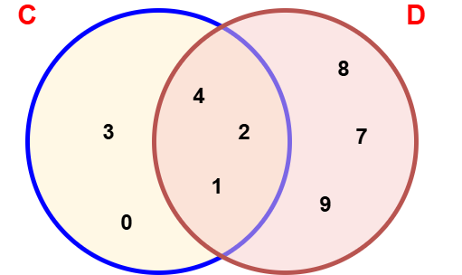

$$C \backslash D = \{0, 3\}$$

```r
setdiff(C, D)
```

```
[1] 0 3
```

$$D \backslash C = \{8, 7, 9\}$$

```r
setdiff(D, C)
```

```
[1] 8 7 9
```

$$C \cap D = \{4, 2, 1\}$$

```r
intersect(C, D)
```

```
[1] 4 2 1
```

```r
intersect(D, C)
```

```
[1] 4 2 1
```

$$C \cup D = \{0, 3, 4, 2, 1, 8, 7, 9 \}$$

```r
union(C, D)
```

```
[1] 0 3 4 2 1 8 7 9
```

$$(C \cup D) \backslash (C\cap D) = \{0, 3, 8, 7, 9 \}$$

```r
setdiff(union(C, D), intersect(C, D))
```

```
[1] 0 3 8 7 9
```

[**Tham khảo chuyên đề R cơ bản về các lệnh reshape và merge dữ liệu (session 6)**](https://www.tuhocr.com/r-basics)

[figure not shown]

# 2 Lý thuyết tổ hợp (Combinatorics)

“Lý thuyết tổ hợp” tiếng Anh là Combinatorics, nghiên cứu cách đếm, sắp xếp và phân chia các đối tượng.

Các từ liên quan:

- Combination:Tổ hợp
- Permutation: Chỉnh hợp / Hoán vị (tùy ngữ cảnh)
- Arrangement: Cách sắp xếp
- Counting principles: Các nguyên lý đếm
- Binomial coefficient: Hệ số nhị thức
- Inclusion–exclusion principle: Nguyên lý bao hàm–loại trừ [Wikipedia](https://en.wikipedia.org/wiki/Inclusion%E2%80%93exclusion_principle)

## 2.1 Quy tắc cộng (Addition Principle)

Một công việc được thực hiện bằng một trong các phương án **không trùng nhau**.

Nếu phương án 1 có $m$ cách, phương án 2 có $n$ cách thì tổng số cách là:

$$\text{Tổng số cách thực hiện} = m + n$$

Ví dụ: Có 3 bút bi và 4 bút chì. Chỉ được chọn 1 chiếc bút (bất kể là bút bi hay bút chì) thì có 3 + 4 = 7 cách chọn.

## 2.2 Quy tắc nhân (Multiplication Principle)

Giả sử một công việc chia thành 2 công đoạn A và B. Công đoạn A có thể thực hiện $m$ cách và ứng với mỗi cách thực hiện công đoạn A thì có $n$ cách thực hiện công đoạn B. Khi đó:

$$\text{Tổng số cách thực hiện} = m \times n$$

Ví dụ: Có 3 áo và 4 quần. Chọn 1 áo và 1 quần thì có 3 × 4 = 12 phương án phối bộ quần áo.

## 2.3 Giai thừa

Giai thừa (factorial) của một số nguyên không âm $n$, ký hiệu $n!$ là tích của tất cả các số nguyên dương từ $1$ đến $n$.

$$n! = 1 \times 2 \times 3 \cdots \times n-1 \times n$$

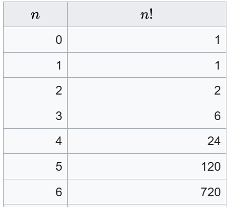

Ví dụ:

$$6! = 1 \times 2 \times 3 \times 4 \times 5 \times 6 = 720$$

```r
factorial(x = 6)
```

```
[1] 720
```

```r
1 * 2 * 3 * 4 * 5 * 6
```

```
[1] 720
```

## 2.4 Tổ hợp chập

Tổ hợp chập $k$ của $n$, tiếng Anh là combination/combinator $n$ objects taken $k$ at a time, (có bao nhiêu cách) chọn $k$ phần tử từ tập hợp gồm $n$ phần tử.

$$\mathrm{C}_{n}^{k} = C(n, k) = \binom{n}{k}=\frac{n!}{k!(n-k)!}$$

$$\binom{n}{k}$$

đọc là “n choose k” hay là “tổ hợp chập k của n”, hay là “k-combination of n elements”

Ta tìm “**số** tổ hợp chập k của n”, “number of combination/combinator $n$ elements taken $k$ at a time.

Ví dụ: Tổ hợp chập 2 của 4. Ta có 4 bạn A, B, C, D. Chọn 2 bạn để tham gia một đội. Hỏi có bao nhiêu cách chọn?

Làm thủ công ta sẽ có 6 cách chọn như sau:

- AB hay BA được xem là 1 cách chọn vì **tổ hợp chập không quan tâm thứ tự.**
- AC
- AD
- BC
- BD
- CD

$$\mathrm{C}_{4}^{2} = C(4, 2) = \binom{4}{2}=\frac{4!}{2!(4-2)!} = \frac{24}{2 \times 2} = 6$$

```r
choose(n = 4, k = 2)
```

```
[1] 6
```

```r
library(combinat)

# generate all combinations of the elements of x taken m at a time.
# kết quả tổ hợp xếp theo cột
# tính tổng số cột bằng lệnh ncol()

kq <- combinat:::combn(x = c("A", "B", "C", "D"),
                       m = 2)

kq
```

```
     [,1] [,2] [,3] [,4] [,5] [,6]
[1,] "A"  "A"  "A"  "B"  "B"  "C"
[2,] "B"  "C"  "D"  "C"  "D"  "D"
```

```r
ncol(kq)
```

```
[1] 6
```

## 2.5 Hoán vị và chỉnh hợp

Đây là cách chọn phần tử từ tập hợp, có xét đến thứ tự, do đó AB và BA là 2 cách chọn khác nhau.

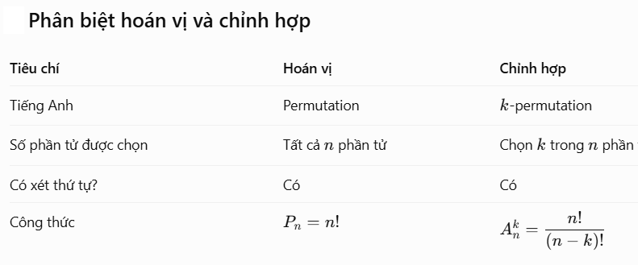

# 3 Tài liệu tham khảo

1. [Lý thuyết tập hợp (Wikipedia)](https://vi.wikipedia.org/wiki/L%C3%BD_thuy%E1%BA%BFt_t%E1%BA%ADp_h%E1%BB%A3p)
2. https://www.mathsisfun.com/combinatorics/combinations-permutations.html
3. Combinatorics: an upper-level introductory course in enumeration, graph theory, and design theory [PDF](https://filedn.com/lesyJpQOCafj7katNqunAxu/THANKS/prob/Combinatorics.pdf)